# Module 1: Data types and structures

PUBHLT0411: Statistical Packages for Public Health Data Analysis

Rebecca Deek, PhD

University of Pittsburgh, Biostatistics and Health Data Science

## Housekeeping/setup

```r
# the code below will load the necessary packages for these slides
# packages are normally loaded using library(packageName) after installing them.
# the `pacman` package has a function called `p_load` that checks if a package is
# installed. If it isn't installed, it will install it, otherwise it will load it.

# this line installs the pacman package, if you need it
if(!require(pacman)){
  install.packages(pacman)
  library(pacman)
}

pacman::p_load(countdown)
pacman::p_load(knitr)
pacman::p_load(kableExtra)
```

## Data types

R has six basic types of data: **double/numeric, integer, logical, character, complex and raw**. We will focus on:

1. **Double [Numeric]**: data that are numbers with decimals.
   - Double refers to how R stores the object in memory.
2. **Integers**: data that are numbers without decimals.
3. **Logical**: data that take the value of either `TRUE` or `FALSE`.
   - Special type for `NA` to represent missing data.
4. **Character**: data that are used to represent strings (e.g., word[s]).
   - Special type: factors, which have ordering (levels).

## Checking data types with `typeof()`

- Often, R can distinguish data types using context.

```r
numb = c(3, 5) # type: numeric
typeof(numb)
```

```
[1] "double"
```

```r
char = "PUBHLT0411" # type: character
typeof(char)
```

```
[1] "character"
```

```r
char2 = "F" # type: character
typeof(char2)
```

```
[1] "character"
```

```r
logi1 = TRUE # type: logical
typeof(logi1)
```

```
[1] "logical"
```

```r
logi2 = F # type: logical
typeof(logi2)
```

```
[1] "logical"
```

- Sometimes you’ll need to explicitly tell R how to treat an object.

## Checking types with a logical test

- Alternatively, there is a family of functions that perform a logical test to determine data types.
  - Outputs are logicals: `TRUE` or `FALSE`.

```r
is.numeric(numb)
```

```
[1] TRUE
```

```r
is.character(numb)
```

```
[1] FALSE
```

```r
is.character(char)
```

```
[1] TRUE
```

```r
is.logical(logi2)
```

```
[1] TRUE
```

## Special case: Checking for `NA`

```r
scalar.na = NA # single value (scalar)
typeof(scalar.na)
```

```
[1] "logical"
```

```r
numb.na = c(3, 5, NA) # vector
is.na(numb.na)
```

```
[1] FALSE FALSE  TRUE
```

- We say that `is.na()` is a *vectorized* function, meaning it checks each element of the vector (automatically) and returns a logical for each index.

```r
is.numeric(numb.na)
```

```
[1] TRUE
```

- `is.numeric()`, and the like (character, logical, etc.), are not vectorized. They look at the overall type of the object.

## Coercion with `c()`

- What happens if we create a vector with mixed types?

```r
mixed.type.vector1 = c(T, 5, 9, FALSE)
mixed.type.vector1 # T/FALSE become numeric
```

```
[1] 1 5 9 0
```

```r
typeof(mixed.type.vector1)
```

```
[1] "double"
```

```r
mixed.type.vector2 = c(1, "abc", "dog", T)
mixed.type.vector2 # 1/T become strings
```

```
[1] "1"    "abc"  "dog"  "TRUE"
```

```r
typeof(mixed.type.vector2)
```

```
[1] "character"
```

- R unifies the vector to the most general type. From least to most general:
  $$\textrm{logical} \rightarrow \textrm{integer} \rightarrow \textrm{double} \rightarrow \textrm{character}$$

## Coercing the type of objects

- There may be times where it will be useful to change the type of a variable using a coercion function.
  - E.g., a study collected blood groups and coded them as: **O = 1; A = 2; B = 3; AB = 4**.

```r
blood.types.numb = c(1, 2, 1, 4, 3, 3) # O, A, O, AB, B, B
typeof(blood.types.numb)
```

```
[1] "double"
```

- R is treating our vector as a numeric but the coding really represents discrete blood types. **Character** data type is more appropriate (or **factor**, up next).

```r
blood.types.char = as.character(blood.types.numb)
blood.types.char
```

```
[1] "1" "2" "1" "4" "3" "3"
```

```r
typeof(blood.types.char)
```

```
[1] "character"
```

- We can coerce back to numeric (but doesn’t always work as expected).

```r
blood.types.numb2 = as.numeric(blood.types.char)
blood.types.numb2
```

```
[1] 1 2 1 4 3 3
```

```r
typeof(blood.types.numb2)
```

```
[1] "double"
```

## Coercing the type of objects

- Coercion does not always work in the way we expect.

```r
eye.color = c("blue", "brown", "green", "gray", "hazel")
eye.color
```

```
[1] "blue"  "brown" "green" "gray"  "hazel"
```

```r
typeof(eye.color)
```

```
[1] "character"
```

```r
# convert to numeric
eye.color.numb = as.numeric(eye.color)
typeof(eye.color.numb)
```

```
[1] "double"
```

```r
eye.color.numb
```

```
[1] NA NA NA NA NA
```

- This is the more standard outcome in R.
  - The prior example worked because our strings were just numbers (no text).
- Generally, R doesn’t know how to convert strings (in this case colors) into numeric values.
  - There is no clear ordering to the colors.

## Factors

- Factors are used for variables that have a fixed and known set of possible values.
  - Also useful if character vectors have a specific order.

```r
day = c("Th", "W", "M", "F", "F",  "T",  "F",  "W" )
sort(day)
```

```
[1] "F"  "F"  "F"  "M"  "T"  "Th" "W"  "W"
```

- Sorting a character vector returns elements in alphabetical order.
- Factors require levels, which can be specified or assumed from the data.
  - Labels are optional and do not have to match levels.

```r
day.levels  = c("M", "T", "W", "Th", "F") # string of levels - in order
# x = vector of data; levels = optional vector of the unique values
day.factor = factor(x = day, levels = day.levels)
day.factor
```

```
[1] Th W  M  F  F  T  F  W
Levels: M T W Th F
```

```r
levels(day.factor)
```

```
[1] "M"  "T"  "W"  "Th" "F"
```

```r
sort(day.factor)
```

```
[1] M  T  W  W  Th F  F  F
Levels: M T W Th F
```

## Factors: `typeof` versus `class`

- R stores factors as integers for efficiency. The integer values correspond to the locations of each element in the levels.

```r
typeof(day.factor)
```

```
[1] "integer"
```

```r
day.factor
```

```
[1] Th W  M  F  F  T  F  W
Levels: M T W Th F
```

```r
as.numeric(day.factor)
```

```
[1] 4 3 1 5 5 2 5 3
```

- `typeof()` tells how an object is stored in R’s internal memory storage. `class()` tells how an object is stored for programming.
  - Similar to how `typeof()` differentiates between `double` and `integer` but `class()` returns `numeric` for both.

```r
class(day.factor)
```

```
[1] "factor"
```

## Factors: Missing and changing levels

- Missing levels are coded as `NA`

```r
day.factor2 = factor(x = c(day, "Sa"), levels = day.levels)
day.factor2
```

```
[1] Th   W    M    F    F    T    F    W    <NA>
Levels: M T W Th F
```

- The first element of the levels is called the reference. This can be changed.

```r
table(day.factor) # count # of obs per day
```

```
day.factor
 M  T  W Th  F
 1  1  2  1  3
```

```r
day.factor.F = relevel(x = day.factor, ref = "F")
day.factor.F
```

```
[1] Th W  M  F  F  T  F  W
Levels: F M T W Th
```

## Data types: Summary

| Type | Logical test | Coercing |
| --- | --- | --- |
| Character | is.character | as.character |
| Numeric | is.numeric | as.numeric |
| Logical | is.logical | as.logical |
| Factor | is.factor | as.factor |
| Complex | is.complex | as.complex |

## Lab 1

## Data structures: Vectors

- Atomic vectors are the basic data structure in R.
- Homogeneous (all one data type) and 1D.
- Important properties: `typeof()`, `length()`, and `attributes()`
- Vectors of length 1 are scalars.

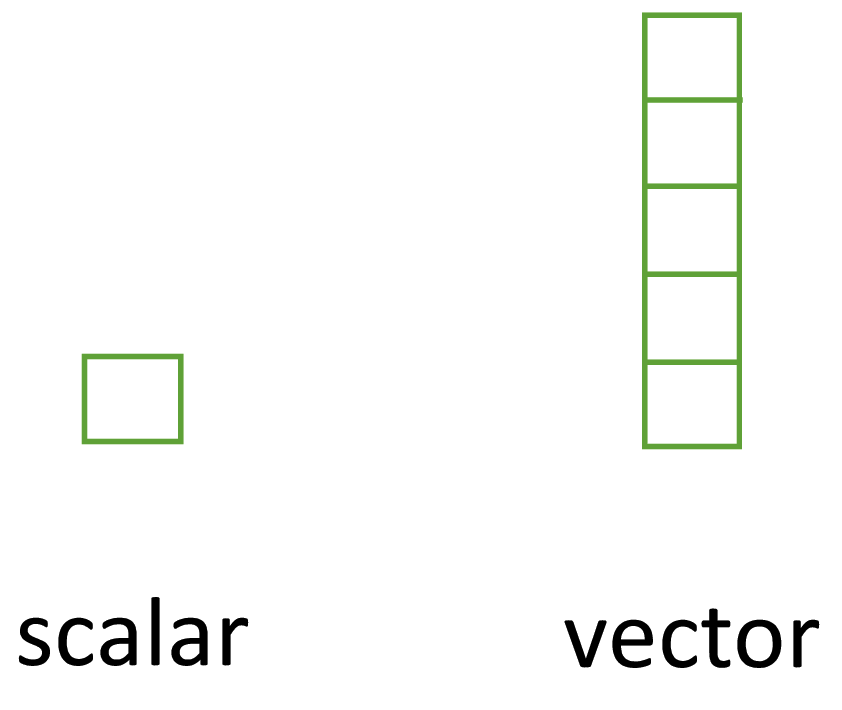

## Functions for vectors

```r
scalar = c(10) # scalar
length(scalar)
```

```
[1] 1
```

```r
vec = c(23, 49, 6, 56, 92) # 5-dimensional vector
length(vec)
```

```
[1] 5
```

- Vectors can be named. Names are considered an attribute.

```r
named.vec = c("e1" = 23, "e2" = 49, "e3" = 6, "e4" = 56, "e5" = 92)
named.vec
```

```
e1 e2 e3 e4 e5
23 49  6 56 92
```

```r
length(named.vec)
```

```
[1] 5
```

```r
names(named.vec)
```

```
[1] "e1" "e2" "e3" "e4" "e5"
```

## Data structures: Matrices and arrays

- Matrices are vectors with an additional dimension (2D).
- Arrays are multidimensional matrices (N-dimensional).
- Matrices and arrays must be homogeneous, containing elements all of the same data type.

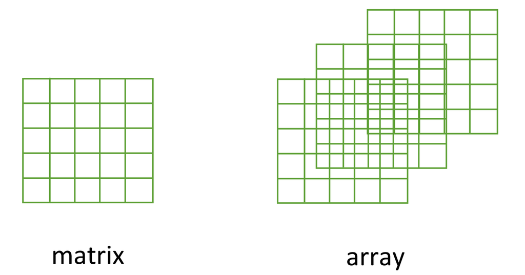

## Matrices and arrays

- Matrices are more common for (bio)statistics.

```r
mat1 = matrix(data = 1:12, nrow = 4, ncol = 3, byrow = TRUE)
mat1
```

```
     [,1] [,2] [,3]
[1,]    1    2    3
[2,]    4    5    6
[3,]    7    8    9
[4,]   10   11   12
```

- Arrays are less common but can still be useful.

```r
array1 = array(data = 1:12, dim = c(2, 3, 2)) # dim: rows, columns, matrices.
array1
```

```
, , 1

     [,1] [,2] [,3]
[1,]    1    3    5
[2,]    2    4    6

, , 2

     [,1] [,2] [,3]
[1,]    7    9   11
[2,]    8   10   12
```

- Order of the `dim` argument: rows, columns, matrices.

## Functions for matrices and arrays

- Generalizations of `length()`: `dim()`, `nrow()`, `ncol()`.

```r
dim(mat1) # rows, columns
```

```
[1] 4 3
```

```r
nrow(mat1)
```

```
[1] 4
```

```r
ncol(mat1)
```

```
[1] 3
```

- Generalizations of `names()`: `rownames()` and `colnames()`.

```r
# call names
rownames(mat1)
```

```r
colnames(mat1)
```

- Can provide/assign names using the same functions:

```r
# provide names
rownames(mat1) = c("r1", "r2", "r3", "r4")
colnames(mat1) = c("c1", "c2", "c3")
rownames(mat1)
```

```
[1] "r1" "r2" "r3" "r4"
```

## Matrix math

```r
sq.mat1 = matrix(data = 1:4, nrow = 2, byrow = TRUE)
sq.mat2 = matrix(data = 5:8, nrow = 2, byrow = TRUE)
sq.mat1
```

```
     [,1] [,2]
[1,]    1    2
[2,]    3    4
```

```r
t(sq.mat1) # transpose
```

```
     [,1] [,2]
[1,]    1    3
[2,]    2    4
```

```r
diag(sq.mat1) # diagonal
```

```
[1] 1 4
```

```r
sq.mat1 + sq.mat2 # addition
```

```
     [,1] [,2]
[1,]    6    8
[2,]   10   12
```

```r
sq.mat1 %*% sq.mat2 # multiplication
```

```
     [,1] [,2]
[1,]   19   22
[2,]   43   50
```

## Comparison of vectors, matrices, arrays

| Vector | Matrix | Array |
| --- | --- | --- |
| names() | rownames(), colnames() | dimnames() |
| length() | dim(), nrow(), ncol() | dim() |
| c() | rbind(), cbind() | abind::abind() |
| — | t() | aperm() |
| is.null(dim(x)) | is.matrix() | is.array() |

## Data structures: Lists

- Lists are heterogeneous, meaning they can store mixtures of data types and structures.
- Ideal for storing irregular or non-rectangular data.

```r
list1 = list(character = c("John Smith", "Jane Doe"),
             double = c(62, 45),
             matrix = matrix(data = 1:4, nrow = 2, byrow = T)
             )
list1
```

```
$character
[1] "John Smith" "Jane Doe"

$double
[1] 62 45

$matrix
     [,1] [,2]
[1,]    1    2
[2,]    3    4
```

```r
names(list1)
```

```
[1] "character" "double"    "matrix"
```

## Renaming lists

- Elements of lists can be renamed used `names()`.

```r
# rename list elements
names(list1) = c("name", "age", "variables")
list1
```

```
$name
[1] "John Smith" "Jane Doe"

$age
[1] 62 45

$variables
     [,1] [,2]
[1,]    1    2
[2,]    3    4
```

## Data structures: Data frames

- Most common structure to store data.
- Similar to matrices (2D) but can be heterogeneous.
  - Different data types per column.
  - Stored in R as a **list** of equal length vectors.
- Rectangular tidy data: all columns must have the same number of observations. Missing data are code as `NA`.

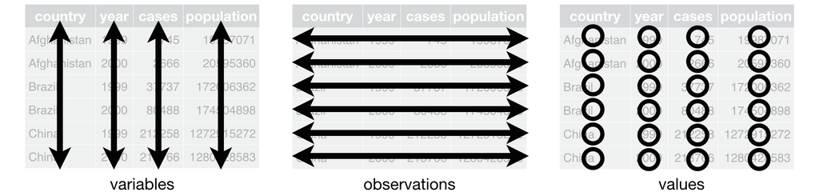

## Functions for data frames

```r
df = data.frame("name" = c("John", "Jane", "William", "Elizabeth"), # variable name = elements syntax
                "age" = c(62, 45, 39, 27),
                "city" = c("PGH", "SEA", "NYC", "CHI"),
                stringsAsFactors = F # keep strings characters
             )
df
```

```
       name age city
1      John  62  PGH
2      Jane  45  SEA
3   William  39  NYC
4 Elizabeth  27  CHI
```

```r
head(df, n = 2)
```

```
  name age city
1 John  62  PGH
2 Jane  45  SEA
```

```r
dim(df) # rows, columns
```

```
[1] 4 3
```

```r
nrow(df)
```

```
[1] 4
```

```r
ncol(df)
```

```
[1] 3
```

```r
str(df)
```

```
'data.frame':   4 obs. of  3 variables:
 $ name: chr  "John" "Jane" "William" "Elizabeth"
 $ age : num  62 45 39 27
 $ city: chr  "PGH" "SEA" "NYC" "CHI"
```

## Coercion and testing data frames

`as.data.frame()` coerces an object to a data frame.

- A vector creates a one-column data frame.

```r
twos = c(2, 4, 6, 8)
vect.to.df = as.data.frame(twos)
vect.to.df
```

```
  twos
1    2
2    4
3    6
4    8
```

```r
is.data.frame(vect.to.df)
```

```
[1] TRUE
```

- A list creates one column for each element. An error is produced if they’re not all the same length.

```r
list.to.df = as.data.frame(list1)
list.to.df
```

```
        name age variables.1 variables.2
1 John Smith  62           1           2
2   Jane Doe  45           3           4
```

```r
is.data.frame(list.to.df)
```

```
[1] TRUE
```

## Coercion and testing data frames

- A matrix creates a data frame with the same dimensions.

```r
mat.to.df = as.data.frame(mat1)
mat.to.df # preserved row/column names
```

```
   c1 c2 c3
r1  1  2  3
r2  4  5  6
r3  7  8  9
r4 10 11 12
```

```r
is.data.frame(mat.to.df)
```

```
[1] TRUE
```

- Binding the rows (vertical stacking) can be helpful for combining two matrices.
  - Must be of the same dimension and have the same column names.

```r
sq.mat1.df = as.data.frame(sq.mat1)
sq.mat2.df = as.data.frame(sq.mat2)
sq.mat1.df # col name automatically assigned matrix -> df
```

```
  V1 V2
1  1  2
2  3  4
```

```r
rbind(sq.mat1.df, sq.mat2.df)
```

```
  V1 V2
1  1  2
2  3  4
3  5  6
4  7  8
```

## Types of subsetting

- Complex operations can be performed succinctly with subsetting objects.
- Three subsetting operators: `[[]]`, `[]`, and `$`.
  - Interact differently with each data structure.
- `[[]]` and `$` select single elements.
  - `$` is a shortcut for `[[`.
- `[]` selects any number of elements.

## Positional subsetting: Vectors

- `[+]`: Keeps elements at specified positions, keeps attributes.
- `[-]`: Drops elements at specified positions, keeps attributes.
- `[[+]]` selects a single element, drops attributes.
- `$` doesn’t work for vectors.

```r
named.vec[]
```

```
e1 e2 e3 e4 e5
23 49  6 56 92
```

```r
named.vec[1]
```

```
e1
23
```

```r
named.vec[-2]
```

```
e1 e3 e4 e5
23  6 56 92
```

```r
named.vec[c(1,3)] # multiple elements in c()
```

```
e1 e3
23  6
```

```r
named.vec[-c(2,4)]
```

```
e1 e3 e5
23  6 92
```

```r
named.vec["e1"]
```

```
e1
23
```

```r
named.vec[["e1"]]
```

```
[1] 23
```

```r
named.vec[[c("e1", "e2")]]
```

```
Error in `named.vec[[c("e1", "e2")]]`:
! attempt to select more than one element in vectorIndex
```

```r
named.vec$e1
```

```
Error in `named.vec$e1`:
! $ operator is invalid for atomic vectors
```

## Positional subsetting: Lists

- `[+/-]` always returns a list with attributes.
- `[[+]]` and `$` returns the object (type) in the called element.

```r
list1[1]
```

```
$name
[1] "John Smith" "Jane Doe"
```

```r
list1[[1]]
```

```
[1] "John Smith" "Jane Doe"
```

```r
list1$name
```

```
[1] "John Smith" "Jane Doe"
```

```r
typeof(list1[1])
```

```
[1] "list"
```

```r
typeof(list1[[1]])
```

```
[1] "character"
```

```r
typeof(list1$name)
```

```
[1] "character"
```

```r
list1[-2]
```

```
$name
[1] "John Smith" "Jane Doe"

$variables
     [,1] [,2]
[1,]    1    2
[2,]    3    4
```

```r
list1[c(1,2)]
```

```
$name
[1] "John Smith" "Jane Doe"

$age
[1] 62 45
```

```r
list1[-c(2,3)]
```

```
$name
[1] "John Smith" "Jane Doe"
```

```r
list1[[c(1,2)]] # no error but not as expected!
```

```
[1] "Jane Doe"
```

## Positional subsetting: Data frames

- `[,+/-]` select or drops one or more **columns**.
- `[+/-,]` select or drops one or more **rows**.
- `[[]]` and `$` select a single column.

```r
df[,1]
```

```
[1] "John"      "Jane"      "William"   "Elizabeth"
```

```r
typeof(df[,1]) # vector
```

```
[1] "character"
```

```r
df[,1:2]
```

```
       name age
1      John  62
2      Jane  45
3   William  39
4 Elizabeth  27
```

```r
typeof(df[,1:2]) # list, class = df
```

```
[1] "list"
```

```r
df[1,]
```

```
  name age city
1 John  62  PGH
```

```r
typeof(df[1,]) # list, class = df
```

```
[1] "list"
```

```r
df[1:2,c(2,3)]
```

```
  age city
1  62  PGH
2  45  SEA
```

```r
df[[2]]
```

```
[1] 62 45 39 27
```

```r
df[["age"]]
```

```
[1] 62 45 39 27
```

```r
df$age
```

```
[1] 62 45 39 27
```

```r
df[[c("age", "city")]]
```

```
Error in `.subset2()`:
! subscript out of bounds
```

```r
df[,c("age", "city")]
```

```
  age city
1  62  PGH
2  45  SEA
3  39  NYC
4  27  CHI
```

## Logical subsetting

- Can only be performed with `[]`.
  - Available logical operators: `>` (greater than), `>=` (greater than or equal to), `<` (less than), `<=` (less than or equal to), `==` (equal to), and `!=` (not equal to).
  - Conditions with `&` indicate “and” statements (check for both conditions). Conditions with `|` indicate “or” statements (check for either condition).

```r
vec
```

```
[1] 23 49  6 56 92
```

```r
vec < 50
```

```
[1]  TRUE  TRUE  TRUE FALSE FALSE
```

```r
vec[vec < 50]
```

```
[1] 23 49  6
```

```r
df$name == "John"
```

```
[1]  TRUE FALSE FALSE FALSE
```

```r
df[df$name == "John",]
```

```
  name age city
1 John  62  PGH
```

```r
df[df$name != "John",]
```

```
       name age city
2      Jane  45  SEA
3   William  39  NYC
4 Elizabeth  27  CHI
```

```r
df[df$city %in% c("PGH", "NYC"),]
```

```
     name age city
1    John  62  PGH
3 William  39  NYC
```

```r
df[df$age > 40,]
```

```
  name age city
1 John  62  PGH
2 Jane  45  SEA
```

```r
df[df$age > 40 & df$city == "PGH", ] # and
```

```
  name age city
1 John  62  PGH
```

```r
df[df$age > 40 | df$city == "PGH", ] # or
```

```
  name age city
1 John  62  PGH
2 Jane  45  SEA
```

```r
list1[names(list1) == "name"]
```

```
$name
[1] "John Smith" "Jane Doe"
```

## Advanced positional subsetting

- We can override/change variables with subsetting.
- Subsets that return the object (type) for lists can be operated on.

```r
df$city = as.factor(df$city)
df$city
```

```
[1] PGH SEA NYC CHI
Levels: CHI NYC PGH SEA
```

```r
city2 = c("BOS", "LA", "SF", "DC")
df$city = city2
df$city
```

```
[1] "BOS" "LA"  "SF"  "DC"
```

```r
df$age * 12
```

```
[1] 744 540 468 324
```

```r
df[[2]] * 12
```

```
[1] 744 540 468 324
```

```r
df[,2] * 12
```

```
[1] 744 540 468 324
```

```r
list1$age * 12
```

```
[1] 744 540
```

```r
list1[["age"]] * 12
```

```
[1] 744 540
```

```r
list1["age"] * 12
```

```
Error in `list1["age"] * 12`:
! non-numeric argument to binary operator
```

## Lab 1